# Distance-based learning with manydist and tidymodels

Author

Alfonso Iodice D’Enza

```r
set.seed(123)
rm(list = ls())
devtools::load_all("../")
# library(manydist)
library(tidyverse)
library(tidymodels)
library(palmerpenguins)
```

# 1 Introduction

The manydist package provides a flexible framework for distance-based learning with continuous, categorical, and mixed-type predictors. Its core function `mdist()` computes mixed-variable dissimilarities under a range of presets and custom specifications, while the `MDist` class stores both the resulting distance matrix and the associated metadata.

The package also integrates with the tidymodels ecosystem through a recipe step, `step_mdist()`, a custom distance-based nearest-neighbour model, `nearest_neighbor_dist()`, a distance-based partitioning around medoids implementation, `pam_dist()`, and a distance-based spectral clustering implementation, `spectral_dist()`.

This vignette illustrates the main functionalities of the package:

1. computing mixed-type distances with `mdist()`;
2. assessing variable influence with `lovo_mdist()`;
3. comparing diagnostics across methods with `compare_lovo_mdist()`;
4. creating distance-based representations with `step_mdist()`;
5. fitting and tuning a KNN model with `nearest_neighbor_dist()`;
6. fitting a distance-based PAM clustering model with `pam_dist()`;
7. fitting a distance-based spectral clustering model with `spectral_dist()`.

The focus is on classification of penguin species, but the same ideas apply to other supervised or unsupervised tasks that rely on pairwise distances.

# 2 Data

We start from the `penguins` data and remove rows with missing values.

```r
penguins_clean <- palmerpenguins::penguins |>
  drop_na()

penguins_clean |>
  dplyr::count(species)
```

```
# A tibble: 3 × 2
  species       n
  <fct>     <int>
1 Adelie      146
2 Chinstrap    68
3 Gentoo      119
```

# 3 Computing mixed-type distances with `mdist()`

The main entry point of the package is `mdist()`, which computes a mixed-variable dissimilarity according to a chosen preset or custom specification.

```r
d_obj_all <- mdist(
  x = penguins_clean |> select(-species),
  preset = "u_dep"
)

summary(d_obj_all)
```

```
MDist summary
  Preset : u_dep
  Observations : 333
  Continuous vars : 5
  Categorical vars: 2

Distance matrix statistics:
  Mean : 7.0211
  SD   : 2.4944
  Min  : 0.2931
  Max  : 17.601
  Diagonal all zeros (block): YES
  Symmetric (block check)   : YES
  Triangle viol. rate (block): 0.000
  NA count:0
  Inf count:0

Commensurable mixed-type distance combining manhattan (continuous) and tvd (categorical) components.
```

The resulting object stores the distance matrix together with the distance specification.

```r
class(d_obj_all)
```

```
[1] "MDist" "R6"
```

```r
dim(base::as.matrix(d_obj_all$distance))
```

```
[1] 333 333
```

# 4 Variable diagnostics with `lovo_mdist()`

The function `lovo_mdist()` provides a leave-one-variable-out diagnostic. For each predictor, the function recomputes the distance after removing that variable and compares the resulting structure with the full-distance solution.

The main user-facing LOVO summaries emphasize:

- `mad_importance`, the average absolute perturbation induced by leaving a variable out;
- `relative_distance`, the relative share of total distance perturbation attributable to the variable;
- `mds_congruence`, a congruence-based measure comparing the leave-one-out and full MDS configurations.

```r
lovo_res <- lovo_mdist(
  x = penguins_clean |> select(-species),
  preset = "u_dep"
)

summary(lovo_res)
```

```
Summary of MDistLOVO
  preset : u_dep
  dims   : 2
  n_obs  : 333
  response used : TRUE

Relative distance:
  range [0.1368, 0.1772], mean 0.1429

Top by relative distance:
# A tibble: 5 × 3
  variable          variable_type relative_distance
  <chr>             <chr>                     <dbl>
1 sex               categorical               0.177
2 bill_length_mm    numeric                   0.138
3 body_mass_g       numeric                   0.137
4 bill_depth_mm     numeric                   0.137
5 flipper_length_mm numeric                   0.137
```

A graphical summary is also available through `autoplot()`.

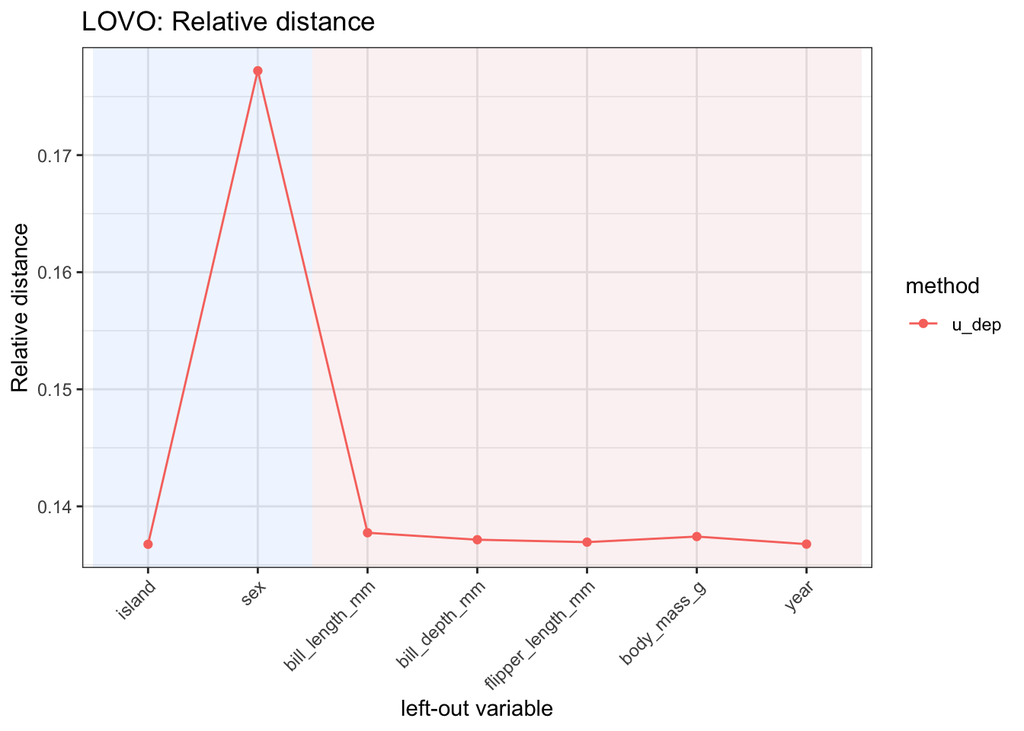

```r
autoplot(lovo_res, metric = "relative_distance")
```

## 4.1 LOVO with clustering-based diagnostics

In addition to distance- and MDS-based diagnostics, `lovo_mdist()` can optionally assess how much the clustering solution changes when each variable is removed. This is activated by specifying the number of clusters through `cluster_k`.

In the next example, we compute leave-one-variable-out diagnostics for the same distance specification as above, and compare the full-data partition with the leave-one-out partitions using both PAM and hierarchical clustering. Agreement is measured through the adjusted Rand index (ARI), while `pam_importance` and `hclust_importance` are defined as `1 - ARI`, so that larger values indicate stronger influence of the left-out variable.

```r
lovo_res_clust <- lovo_mdist(
  x = penguins_clean |> select(-species),
  preset = "u_dep",
  cluster_k = 3
)

summary(lovo_res_clust)
```

```
Summary of MDistLOVO
  preset : u_dep
  dims   : 2
  n_obs  : 333
  response used : TRUE
  cluster_k : 3
  cluster methods : pam, hclust, spectral
  hclust linkage : average

Relative distance:
  range [0.1368, 0.1772], mean 0.1429

Top by relative distance:
# A tibble: 5 × 3
  variable          variable_type relative_distance
  <chr>             <chr>                     <dbl>
1 sex               categorical               0.177
2 bill_length_mm    numeric                   0.138
3 body_mass_g       numeric                   0.137
4 bill_depth_mm     numeric                   0.137
5 flipper_length_mm numeric                   0.137

ARI vs full PAM partition:
  range [0.1099, 0.9625], mean 0.5389

ARI vs full HCLUST partition:
  range [0.0078, 1.0000], mean 0.6311

ARI vs full spectral partition:
  range [0.1661, 1.0000], mean 0.6741
```

The clustering-based importance measures can be visualized with `autoplot()` in the same way as the original LOVO diagnostics.

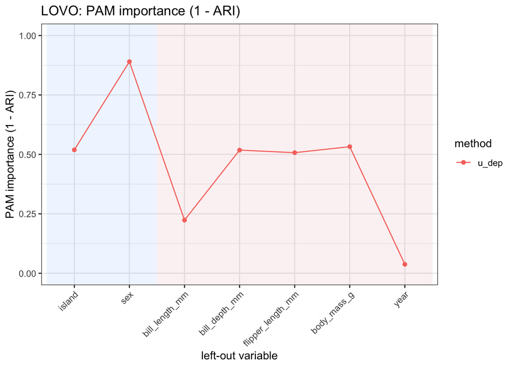

```r
autoplot(lovo_res_clust, metric = "pam_importance")
```

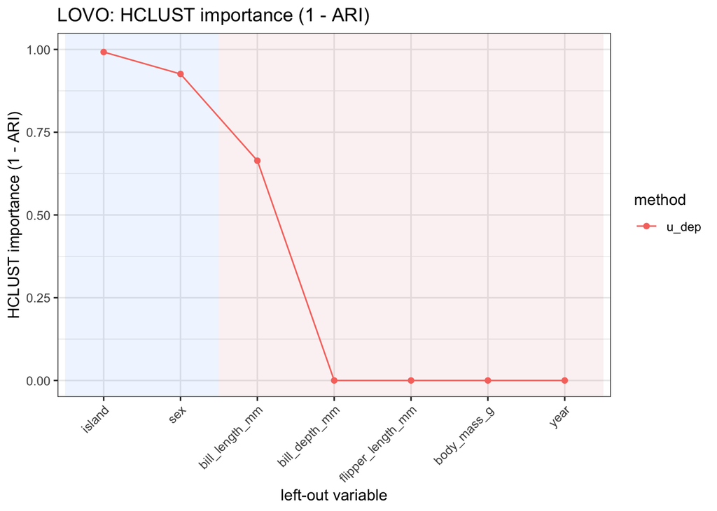

```r
autoplot(lovo_res_clust, metric = "hclust_importance")
```

If needed, only one clustering method can be requested.

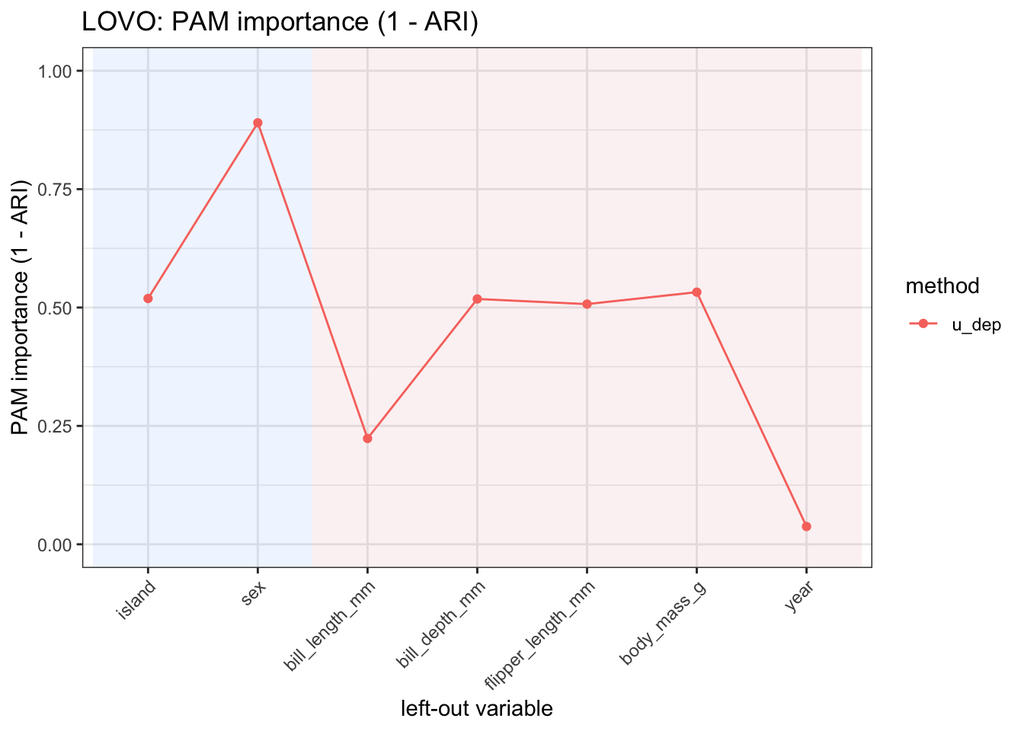

```r
lovo_res_pam <- lovo_mdist(
  x = penguins_clean |> select(-species),
  preset = "u_dep",
  cluster_k = 3,
  cluster_methods = "pam"
)

autoplot(lovo_res_pam, metric = "pam_importance")
```

# 5 Comparing distance specifications with `compare_lovo_mdist()`

The function `compare_lovo_mdist()` extends the LOVO diagnostic to multiple distance specifications. This makes it possible to compare how variable contributions change across alternative mixed-type distances.

In the example below, we compare:

- `"gower"`, a standard mixed-type distance;
- `"u_dep"`, an association-aware distance that enforces commensurability;
- a custom specification based on Manhattan distance for numeric variables and Hennig–Liao distance for categorical variables.

```r
lovo_cmp <- compare_lovo_mdist(
  x = penguins_clean |> select(-species),
  methods = list(
    gower = list(preset = "gower"),
    u_dep = list(preset = "u_dep"),
    custom = list(
      distance_cont = "manhattan",
      distance_cat  = "HL",
      commensurable = FALSE
    )
  )
)

lovo_cmp
```

```
MDistLOVOCompare object
  methods: gower, u_dep, custom
  dims   : 2
  n_obs  : 333
  rows   : 21

Top variables within each method:
# A tibble: 9 × 5
  method variable          variable_type relative_distance mad_importance
  <fct>  <chr>             <chr>                     <dbl>          <dbl>
1 gower  island            categorical               0.143           1.00
2 gower  bill_length_mm    numeric                   0.143           1.00
3 gower  sex               categorical               0.143           1
4 u_dep  sex               categorical               0.177           1.30
5 u_dep  bill_length_mm    numeric                   0.138           1.01
6 u_dep  body_mass_g       numeric                   0.137           1.00
7 custom bill_length_mm    numeric                   0.148           1.15
8 custom bill_depth_mm     numeric                   0.148           1.14
9 custom flipper_length_mm numeric                   0.147           1.14
```

```r
summary(lovo_cmp)
```

```
Summary of MDistLOVOCompare
  methods: gower, u_dep, custom
  dims   : 2
  n_obs  : 333

# A tibble: 3 × 13
  method mad_min mad_max mad_mean rel_min rel_max rel_mean mds_min mds_max
  <fct>    <dbl>   <dbl>    <dbl>   <dbl>   <dbl>    <dbl>   <dbl>   <dbl>
1 gower    1.000    1.00     1      0.143   0.143    0.143   0.946   0.999
2 u_dep    1.000    1.30     1.04   0.137   0.177    0.143   0.850   0.999
3 custom   1.00     1.15     1.11   0.129   0.148    0.143   0.949   0.999
# ℹ 4 more variables: mds_mean <dbl>, ac_min <dbl>, ac_max <dbl>, ac_mean <dbl>
```

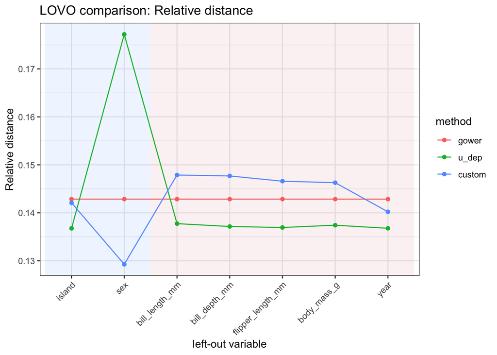

```r
autoplot(lovo_cmp, metric = "relative_distance")
```

# 6 Distance-based KNN in base R

We now move to a simple predictive setting and create a stratified train/test split.

```r
set.seed(123)
peng_split <- initial_split(penguins_clean, strata = species)
peng_train <- training(peng_split)
peng_test  <- testing(peng_split)

dim(peng_train)
```

```
[1] 249   8
```

```r
dim(peng_test)
```

```
[1] 84  8
```

We separate predictors and outcome:

```r
x_train <- peng_train |>
  select(-species)
x_test  <- peng_test |>
  select(-species)
y_train <- peng_train$species
y_test  <- peng_test$species
```

We compute train-to-test distances with `mdist()`.

```r
test_d_obj <- mdist(
  x = x_train,
  new_data = x_test,
  preset = "u_dep"
)

summary(test_d_obj)
```

```
MDist summary
  Preset : u_dep
  Train-test matrix : 249 train x 84 test
  Continuous vars : 5
  Categorical vars: 2

Distance matrix statistics (on preview block):
  Mean : 5.3685
  SD   : 2.2148
  Min  : 0.717
  Max  : 11.2562
  NA count (block):0
  Inf count (block):0

Commensurable mixed-type distance combining manhattan (continuous) and tvd (categorical) components.
```

```r
distance_matrix <- base::as.matrix(test_d_obj$distance)
dim(distance_matrix)
```

```
[1]  84 249
```

These distances can be used directly in a minimal KNN implementation.

```r
n_neighbours <- 5

nn_idx <- apply(distance_matrix, 1, function(d) order(d)[1:n_neighbours])

pred_base <- apply(nn_idx, 2, function(idx) {
  names(which.max(table(y_train[idx])))
})

mean(pred_base == y_test)
```

```
[1] 0.9761905
```

# 7 Distance-based representations with `step_mdist()`

To integrate with `tidymodels`, manydist provides the recipe step `step_mdist()`, which computes dissimilarities relative to the training set.

- `"distance_to_training"` (default): a rectangular test-to-training distance matrix, suited to supervised learners such as KNN;
- `"pairwise"`: a square within-sample distance matrix, suited to clustering and other unsupervised methods.

```r
peng_rec <- recipe(species ~ ., data = peng_train) |>
  step_mdist(all_predictors(), preset = "u_dep")

peng_rec
```

```
Step: mdist
  role:        predictor
  trained:     FALSE

  output:      distance_to_training
  preset:      u_dep
  (arguments handled internally by preset)
```

```r
prepped_rec <- peng_rec |>
  prep()
```

As a quick sanity check, the distance matrix obtained through the recipe matches the one computed directly with `mdist()`.

```r
train_dist <- bake(prepped_rec, new_data = peng_train)
prepped_test_d_obj <- bake(prepped_rec, new_data = peng_test)

sum(prepped_test_d_obj |> select(-species) - test_d_obj$distance)
```

```
[1] 0
```

# 8 Distance-based KNN with `nearest_neighbor_dist()`

The package also provides a custom parsnip model, `nearest_neighbor_dist()`, with a `"precomputed"` engine.

```r
knn_spec <- nearest_neighbor_dist(
  mode = "classification",
  neighbors = 5
) |>
  set_engine("precomputed")

knn_spec
```

```
nearest neighbor dist Model Specification (classification)

Main Arguments:
  neighbors = 5

Computational engine: precomputed
```

We can combine the recipe and the model in a workflow.

```r
peng_wf <- workflow() |>
  add_recipe(peng_rec) |>
  add_model(knn_spec)

peng_wf
```

```
══ Workflow ════════════════════════════════════════════════════════════════════
Preprocessor: Recipe
Model: nearest_neighbor_dist()

── Preprocessor ────────────────────────────────────────────────────────────────
1 Recipe Step

• step_mdist()

── Model ───────────────────────────────────────────────────────────────────────
nearest neighbor dist Model Specification (classification)

Main Arguments:
  neighbors = 5

Computational engine: precomputed
```

```r
peng_fit <- peng_wf |>
  fit(data = peng_train)
```

Predictions and performance evaluation are then straightforward.

```r
peng_pred <- predict(peng_fit, new_data = peng_test, type = "prob") |>
  bind_cols(
    predict(peng_fit, new_data = peng_test, type = "class"),
    peng_test |> select(species)
  )

peng_pred |>
  head()
```

```
# A tibble: 6 × 5
  .pred_Adelie .pred_Chinstrap .pred_Gentoo .pred_class species
         <dbl>           <dbl>        <dbl> <fct>       <fct>
1          1               0              0 Adelie      Adelie
2          0.8             0.2            0 Adelie      Adelie
3          1               0              0 Adelie      Adelie
4          1               0              0 Adelie      Adelie
5          1               0              0 Adelie      Adelie
6          1               0              0 Adelie      Adelie
```

```r
peng_pred |>
  accuracy(truth = species, estimate = .pred_class)
```

```
# A tibble: 1 × 3
  .metric  .estimator .estimate
  <chr>    <chr>          <dbl>
1 accuracy multiclass     0.976
```

# 9 Tuning the number of neighbors

Because `nearest_neighbor_dist()` is registered as a parsnip model, its hyperparameters can be tuned using `tune_grid()`.

```r
knn_tune_spec <- nearest_neighbor_dist(
  mode = "classification",
  neighbors = tune()
) |>
  set_engine("precomputed")

knn_tune_spec
```

```
nearest neighbor dist Model Specification (classification)

Main Arguments:
  neighbors = tune()

Computational engine: precomputed
```

```r
peng_wf_tune <- workflow() |>
  add_recipe(peng_rec) |>
  add_model(knn_tune_spec)
```

```r
set.seed(123)
peng_folds <- vfold_cv(peng_train, v = 5, strata = species)

k_grid <- tibble(neighbors = seq(3, 15, by = 2))
k_grid
```

```
# A tibble: 7 × 1
  neighbors
      <dbl>
1         3
2         5
3         7
4         9
5        11
6        13
7        15
```

```r
peng_metrics <- metric_set(accuracy)

tuned_knn <- tune_grid(
  peng_wf_tune,
  resamples = peng_folds,
  grid = k_grid,
  metrics = peng_metrics
)
```

```r
collect_metrics(tuned_knn)
```

```
# A tibble: 7 × 7
  neighbors .metric  .estimator  mean     n std_err .config
      <dbl> <chr>    <chr>      <dbl> <int>   <dbl> <chr>
1         3 accuracy multiclass 0.984     5 0.00774 pre0_mod1_post0
2         5 accuracy multiclass 0.988     5 0.00494 pre0_mod2_post0
3         7 accuracy multiclass 0.984     5 0.00403 pre0_mod3_post0
4         9 accuracy multiclass 0.984     5 0.00398 pre0_mod4_post0
5        11 accuracy multiclass 0.984     5 0.00398 pre0_mod5_post0
6        13 accuracy multiclass 0.984     5 0.00398 pre0_mod6_post0
7        15 accuracy multiclass 0.984     5 0.00398 pre0_mod7_post0
```

```r
show_best(tuned_knn, metric = "accuracy")
```

```
# A tibble: 5 × 7
  neighbors .metric  .estimator  mean     n std_err .config
      <dbl> <chr>    <chr>      <dbl> <int>   <dbl> <chr>
1         5 accuracy multiclass 0.988     5 0.00494 pre0_mod2_post0
2         9 accuracy multiclass 0.984     5 0.00398 pre0_mod4_post0
3        11 accuracy multiclass 0.984     5 0.00398 pre0_mod5_post0
4        13 accuracy multiclass 0.984     5 0.00398 pre0_mod6_post0
5        15 accuracy multiclass 0.984     5 0.00398 pre0_mod7_post0
```

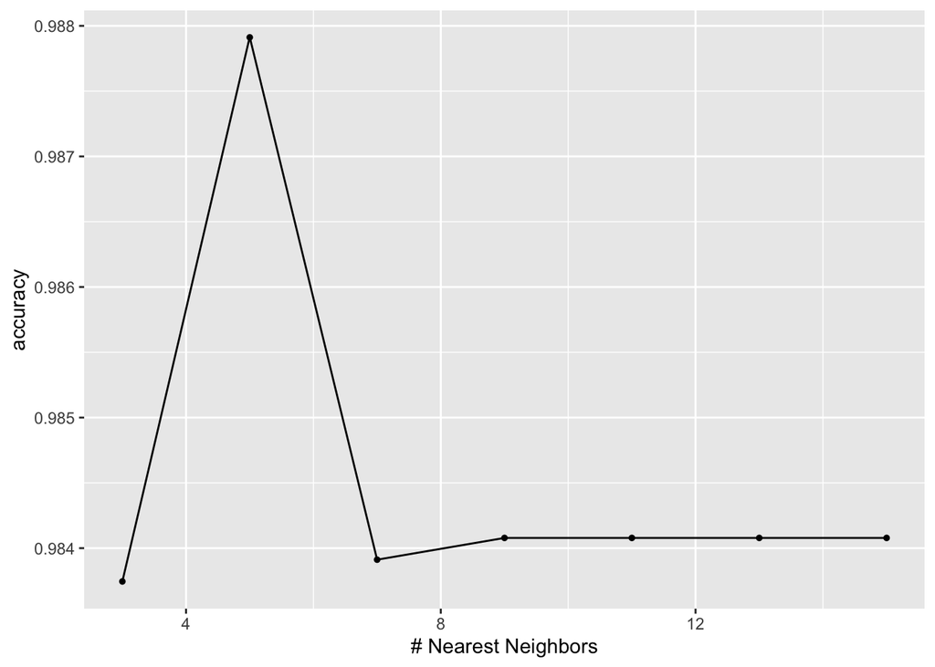

```r
autoplot(tuned_knn)
```

After selecting the best value of `k`, the workflow can be finalized and re-fitted on the training set.

```r
best_k <- select_best(tuned_knn, metric = "accuracy")

final_wf <- peng_wf_tune |>
  finalize_workflow(best_k)

final_fit <- final_wf |>
  fit(data = peng_train)

final_pred <- predict(final_fit, new_data = peng_test, type = "class") |>
  bind_cols(peng_test |> select(species))

final_pred |>
  accuracy(truth = species, estimate = .pred_class)
```

```
# A tibble: 1 × 3
  .metric  .estimator .estimate
  <chr>    <chr>          <dbl>
1 accuracy multiclass     0.976
```

# 10 Distance-based clustering with `pam_dist()` and `spectral_dist()`

For clustering, `step_mdist()` is used with `output = "pairwise"`, so that the within-training pairwise dissimilarity matrix is computed and passed to the clustering method.

We first define a recipe that computes the pairwise dissimilarity matrix on the training set.

```r
peng_rec_clust <- recipe(~ ., data = peng_train |> select(-species)) |>
  step_mdist(
    all_predictors(),
    preset = "u_dep",
    output = "pairwise"
  )

peng_rec_clust
```

```
Step: mdist
  role:        predictor
  trained:     FALSE

  output:      pairwise
  preset:      u_dep
  (arguments handled internally by preset)
```

## 10.1 Distance-based PAM clustering with `pam_dist()`

We define a PAM clustering specification with three clusters.

```r
pam_spec <- pam_dist(num_clusters = 3)

pam_spec
```

```
PAM distance clustering specification
  num_clusters : 3
  engine       : manydist
```

The model is then fitted by combining the specification with the recipe and the training predictors.

```r
pam_fit <- generics::fit(
  pam_spec,
  recipe = peng_rec_clust,
  data = peng_train |> select(-species)
)

pam_fit
```

```
pam_dist fit
  num_clusters : 3
  n_obs        : 249
  medoid idx   : 135, 68, 204
```

The fitted object returns cluster memberships for the training set.

```r
pam_train_pred <- predict(pam_fit)

pam_train_pred |>
  head()
```

```
# A tibble: 6 × 1
  .pred_cluster
  <fct>
1 1
2 1
3 1
4 2
5 1
6 2
```

Since the true penguin species are known, we can compare the obtained partition with the observed classes using the adjusted Rand index (ARI).

```r
mclust::adjustedRandIndex(
  as.integer(pam_train_pred$.pred_cluster),
  as.integer(peng_train$species)
)
```

```
[1] 0.3604109
```

For new observations, `pam_dist()` computes distances from the test set to the training set, extracts the distances to the fitted medoids, and assigns each observation to its nearest medoid.

```r
pam_test_pred <- predict(
  pam_fit,
  new_data = peng_test |> select(-species)
)

pam_test_pred |>
  head()
```

```
# A tibble: 6 × 1
  .pred_cluster
  <fct>
1 2
2 1
3 2
4 1
5 1
6 3
```

The corresponding ARI on the test set is:

```r
mclust::adjustedRandIndex(
  as.integer(pam_test_pred$.pred_cluster),
  as.integer(peng_test$species)
)
```

```
[1] 0.210267
```

If desired, the distances from each test observation to the medoids can also be extracted directly.

```r
predict(
  pam_fit,
  new_data = peng_test |> select(-species),
  type = "dist"
) |>
  head()
```

```
# A tibble: 6 × 3
  medoid_1 medoid_2 medoid_3
     <dbl>    <dbl>    <dbl>
1     7.32     4.34     7.54
2     3.97     6.39     8.86
3     8.85     4.48     8.01
4     4.35     5.81     8.50
5     6.19     6.75     6.22
6     7.46     4.57     4.46
```

## 10.2 Distance-based spectral clustering with `spectral_dist()`

The usage of `spectral_dist()` parallels that of `pam_dist()`: the model can be fitted either on the pairwise training dissimilarity matrix computed by `step_mdist()`, or directly from a precomputed distance object such as the output of `mdist()`.

We define a spectral clustering specification with three clusters.

```r
spectral_spec <- spectral_dist(
  num_clusters = 3
)

spectral_spec
```

```
Spectral distance clustering specification
  num_clusters : 3
  sigma        : NULL (median heuristic)
  nstart       : 50
  engine       : manydist
```

The recipe-based model is fitted in the same way as `pam_dist()`.

```r
spectral_fit <- generics::fit(
  spectral_spec,
  recipe = peng_rec_clust,
  data = peng_train |> select(-species)
)

spectral_fit
```

```
spectral_dist fit
  num_clusters : 3
  n_obs        : 249
  sigma        : 7.052765
  nstart       : 50
```

The fitted object returns cluster memberships for the training set.

```r
spectral_train_pred <- predict(spectral_fit)

spectral_train_pred |>
  head()
```

```
# A tibble: 6 × 1
  .pred_cluster
  <fct>
1 1
2 1
3 1
4 2
5 1
6 2
```

As for PAM, the resulting partition can be compared with the observed penguin species using the adjusted Rand index.

```r
mclust::adjustedRandIndex(
  as.integer(spectral_train_pred$.pred_cluster),
  as.integer(peng_train$species)
)
```

```
[1] 0.12579
```

Predictions for new observations are obtained through the stored distance preprocessor and an out-of-sample extension of the spectral embedding.

```r
spectral_test_pred <- predict(
  spectral_fit,
  new_data = peng_test |> select(-species)
)

spectral_test_pred |>
  head()
```

```
# A tibble: 6 × 1
  .pred_cluster
  <fct>
1 2
2 1
3 2
4 1
5 1
6 3
```

The corresponding ARI on the test set is:

```r
mclust::adjustedRandIndex(
  as.integer(spectral_test_pred$.pred_cluster),
  as.integer(peng_test$species)
)
```

```
[1] 0.05340607
```

If desired, the spectral embedding coordinates can also be extracted directly.

```r
predict(spectral_fit, type = "embed") |>
  head()
```

```
# A tibble: 6 × 3
   dim_1  dim_2  dim_3
   <dbl>  <dbl>  <dbl>
1 -0.495 -0.631 -0.597
2 -0.516 -0.472 -0.714
3 -0.568 -0.627 -0.533
4 -0.496  0.593 -0.635
5 -0.506 -0.644 -0.573
6 -0.448  0.516 -0.730
```

```r
predict(
  spectral_fit,
  new_data = peng_test |> select(-species),
  type = "embed"
) |>
  head()
```

```
# A tibble: 6 × 3
   dim_1  dim_2  dim_3
   <dbl>  <dbl>  <dbl>
1 -0.610  0.378 -0.696
2 -0.577 -0.624 -0.527
3 -0.476  0.479 -0.737
4 -0.566 -0.601 -0.564
5 -0.795 -0.587  0.153
6 -0.826  0.479  0.297
```

## 10.3 Sanity check: direct distance matrix versus recipe-based clustering

Before illustrating the two clustering interfaces, we verify that the recipe-based workflow is consistent with the direct use of `mdist()`.

We first compute the training dissimilarity matrix directly with `mdist()`.

```r
d_train_obj <- mdist(
  x = peng_train |> select(-species),
  preset = "u_dep"
)

D_train_direct <- as.matrix(d_train_obj$distance)
dim(D_train_direct)
```

```
[1] 249 249
```

We then fit PAM directly on this matrix.

```r
pam_direct <- cluster::pam(
  x = stats::as.dist(D_train_direct),
  k = 3,
  diss = TRUE
)

pam_direct_clust <- pam_direct$clustering
head(pam_direct_clust)
```

```
1 2 3 4 5 6
1 1 1 2 1 2
```

Now we fit the recipe-based `pam_dist()` model.

```r
pam_spec <- pam_dist(num_clusters = 3)

pam_fit <- generics::fit(
  pam_spec,
  recipe = peng_rec_clust,
  data = peng_train |> select(-species)
)

pam_recipe_clust <- predict(pam_fit)$.pred_cluster |>
  as.integer()

head(pam_recipe_clust)
```

```
[1] 1 1 1 2 1 2
```

The two PAM partitions coincide up to label permutation. We check this through the adjusted Rand index.

```r
mclust::adjustedRandIndex(
  pam_direct_clust,
  pam_recipe_clust
)
```

```
[1] 1
```

We can do the same for spectral clustering, this time using the public direct-distance interface provided by `spectral_dist()`.

```r
spectral_direct_spec <- spectral_dist(num_clusters = 3)

spectral_direct_fit <- generics::fit(
  spectral_direct_spec,
  x = d_train_obj
)

spectral_direct_clust <- predict(spectral_direct_fit)$.pred_cluster |>
  as.integer()

head(spectral_direct_clust)
```

```
[1] 3 3 3 2 3 2
```

Now fit the recipe-based `spectral_dist()` model.

```r
spectral_spec <- spectral_dist(num_clusters = 3)

spectral_fit <- generics::fit(
  spectral_spec,
  recipe = peng_rec_clust,
  data = peng_train |> select(-species)
)

spectral_recipe_clust <- predict(spectral_fit)$.pred_cluster |>
  as.integer()

head(spectral_recipe_clust)
```

```
[1] 2 2 2 3 2 3
```

Again, we compare the resulting partitions via the adjusted Rand index.

```r
mclust::adjustedRandIndex(
  spectral_direct_clust,
  spectral_recipe_clust
)
```

```
[1] 1
```

An ARI equal to 1 confirms that the clustering obtained through the recipe-based pipeline matches the one obtained by first computing the distance matrix with `mdist()` and then applying the clustering method through the direct distance-based interface.

## 10.4 Consistency checks on continuous data

In the special case of purely continuous predictors, the downstream interfaces provided by **manydist** should be consistent with the corresponding standard methods applied directly to the original data matrix under Euclidean geometry. For simplicity, we illustrate these checks on continuous data only, since Euclidean distance provides a natural and unambiguous reference in that setting. We then verify this for distance computation, nearest neighbours, PAM clustering, and spectral clustering. We start by restricting the penguin data to continuous predictors only.

```r
library(class)
library(cluster)
library(kernlab)
library(mclust)

peng_train_cont <- peng_train |>
  select(species, where(is.numeric))

peng_test_cont <- peng_test |>
  select(species, where(is.numeric))

x_train_cont <- peng_train_cont |> select(-species)
x_test_cont  <- peng_test_cont  |> select(-species)
y_train_cont <- peng_train_cont$species
y_test_cont  <- peng_test_cont$species

X_train <- as.matrix(x_train_cont)
X_test  <- as.matrix(x_test_cont)

k_knn   <- 5
k_clust <- 3
```

### 10.4.1 Euclidean distances: direct computation versus `mdist()`

We first verify that `mdist()` reproduces ordinary Euclidean distances on continuous data when used with Euclidean distance, no scaling, and no commensurability correction.

```r
D_train_eucl <- as.matrix(stats::dist(X_train))

.euclid_block <- function(x_new, x_ref) {
  x_new <- as.matrix(x_new)
  x_ref <- as.matrix(x_ref)

  n_new <- nrow(x_new)
  all_x <- rbind(x_new, x_ref)
  D_all <- as.matrix(stats::dist(all_x))

  D_all[seq_len(n_new), n_new + seq_len(nrow(x_ref)), drop = FALSE]
}

D_test_train_eucl <- .euclid_block(X_test, X_train)

d_train_mdist <- mdist(
  x = x_train_cont,
  distance_cont = "euclidean",
  scaling_cont = "none",
  commensurable = FALSE
)

D_train_mdist <- as.matrix(d_train_mdist$distance)

d_test_mdist <- mdist(
  x = x_train_cont,
  new_data = x_test_cont,
  distance_cont = "euclidean",
  scaling_cont = "none",
  commensurable = FALSE
)

D_test_train_mdist <- as.matrix(d_test_mdist$distance)
```

```r
distance_check <- tibble::tibble(
  dataset = c("train", "test"),
  check = c(
    "base Euclidean vs mdist() max abs diff",
    "test-to-train Euclidean vs mdist() max abs diff"
  ),
  value = c(
    max(abs(D_train_eucl - D_train_mdist)),
    max(abs(D_test_train_eucl - D_test_train_mdist))
  )
)

distance_check
```

```
# A tibble: 2 × 3
  dataset check                                              value
  <chr>   <chr>                                              <dbl>
1 train   base Euclidean vs mdist() max abs diff          7.11e-15
2 test    test-to-train Euclidean vs mdist() max abs diff 1.78e-15
```

### 10.4.2 KNN: direct Euclidean KNN versus `nearest_neighbor_dist()`

We now compare standard KNN on the original continuous predictors with the `manydist` interface based on Euclidean dissimilarities.

```r
knn_direct_pred <- class::knn(
  train = X_train,
  test  = X_test,
  cl    = y_train_cont,
  k     = k_knn
)
```

The corresponding `manydist` pipeline uses `step_mdist()` to compute the Euclidean test-to-training distance representation.

```r
rec_knn_cont <- recipe(species ~ ., data = peng_train_cont) |>
  step_mdist(
    all_predictors(),
    distance_cont = "euclidean",
    scaling_cont = "none",
    commensurable = FALSE
  )

knn_spec_cont <- nearest_neighbor_dist(
  mode = "classification",
  neighbors = k_knn
) |>
  set_engine("precomputed")

wf_knn_cont <- workflow() |>
  add_recipe(rec_knn_cont) |>
  add_model(knn_spec_cont)

knn_fit_cont <- fit(wf_knn_cont, data = peng_train_cont)

knn_manydist_pred <- predict(
  knn_fit_cont,
  new_data = peng_test_cont,
  type = "class"
)$.pred_class
```

We compare the direct and manydist-based predictions through exact agreement and report the manydist classification accuracy on the test set.

```r
knn_check <- tibble::tibble(
  dataset = c("test", "test"),
  check = c(
    "direct vs manydist exact agreement",
    "manydist accuracy"
  ),
  value = c(
    mean(knn_direct_pred == knn_manydist_pred),
    yardstick::accuracy_vec(y_test_cont, knn_manydist_pred)
  )
)

knn_check
```

```
# A tibble: 2 × 3
  dataset check                              value
  <chr>   <chr>                              <dbl>
1 test    direct vs manydist exact agreement 0.988
2 test    manydist accuracy                  0.810
```

### 10.4.3 PAM: direct Euclidean PAM versus `pam_dist()`

For PAM clustering, the direct reference is `cluster::pam()` applied to the original continuous feature matrix with Euclidean metric.

```r
pam_direct_fit <- cluster::pam(
  x = X_train,
  k = k_clust,
  metric = "euclidean"
)

pam_direct_train <- pam_direct_fit$clustering
```

The corresponding `manydist` interface is based on a pairwise Euclidean dissimilarity matrix produced through `step_mdist(..., output = "pairwise")`.

```r
rec_clust_cont <- recipe(~ ., data = x_train_cont) |>
  step_mdist(
    all_predictors(),
    distance_cont = "euclidean",
    scaling_cont = "none",
    commensurable = FALSE,
    output = "pairwise"
  )

pam_spec_cont <- pam_dist(num_clusters = k_clust)

pam_manydist_fit <- generics::fit(
  pam_spec_cont,
  recipe = rec_clust_cont,
  data = x_train_cont
)

pam_manydist_train <- predict(pam_manydist_fit)$.pred_cluster |>
  as.integer()
```

We compare the two training partitions via the adjusted Rand index.

```r
pam_check <- tibble::tibble(
  dataset = "train",
  check = "direct vs manydist partition ARI",
  value = mclust::adjustedRandIndex(pam_direct_train, pam_manydist_train)
)

pam_check
```

```
# A tibble: 1 × 3
  dataset check                            value
  <chr>   <chr>                            <dbl>
1 train   direct vs manydist partition ARI     1
```

### 10.4.4 Spectral clustering: direct Gaussian-kernel clustering versus `spectral_dist()`

For spectral clustering, we compare `spectral_dist()` with a direct spectral clustering benchmark on the original continuous data using `kernlab::specc()` and a Gaussian kernel. The Gaussian bandwidth is matched to the median Euclidean distance used by the manydist implementation.

```r
sigma_sc <- stats::median(D_train_eucl[upper.tri(D_train_eucl)])
gamma_kernlab <- 1 / (2 * sigma_sc^2)

set.seed(123)
spectral_direct_train <- kernlab::specc(
  x = X_train,
  centers = k_clust,
  kernel = "rbfdot",
  kpar = list(sigma = gamma_kernlab)
)

spectral_direct_train <- as.integer(spectral_direct_train)
```

The corresponding `manydist` interface uses the same number of clusters and bandwidth, and is fitted on the pairwise Euclidean dissimilarity matrix produced by `step_mdist()`.

```r
spectral_spec_cont <- spectral_dist(
  num_clusters = k_clust,
  sigma = sigma_sc
)

set.seed(123)
spectral_manydist_fit <- generics::fit(
  spectral_spec_cont,
  recipe = rec_clust_cont,
  data = x_train_cont
)

spectral_manydist_train <- predict(spectral_manydist_fit)$.pred_cluster |>
  as.integer()
```

We again compare the two training partitions via the adjusted Rand index.

```r
spectral_check <- tibble::tibble(
  dataset = "train",
  check = "direct vs manydist partition ARI",
  value = mclust::adjustedRandIndex(spectral_direct_train, spectral_manydist_train)
)

spectral_check
```

```
# A tibble: 1 × 3
  dataset check                            value
  <chr>   <chr>                            <dbl>
1 train   direct vs manydist partition ARI     1
```

### 10.4.5 Summary of consistency checks

We finally collect the results into a single summary table.

```r
sanity_summary <- tibble::tibble(
  method = c(
    "Distance matrix",
    "Distance matrix",
    "KNN",
    "KNN",
    "PAM",
    "Spectral"
  ),
  dataset = c(
    "train",
    "test",
    "test",
    "test",
    "train",
    "train"
  ),
  check = c(
    "base Euclidean vs mdist() max abs diff",
    "test-to-train Euclidean vs mdist() max abs diff",
    "direct vs manydist exact agreement",
    "manydist accuracy",
    "direct vs manydist partition ARI",
    "direct vs manydist partition ARI"
  ),
  value = c(
    distance_check$value[1],
    distance_check$value[2],
    knn_check$value[1],
    knn_check$value[2],
    pam_check$value,
    spectral_check$value
  )
)

sanity_summary
```

```
# A tibble: 6 × 4
  method          dataset check                                            value
  <chr>           <chr>   <chr>                                            <dbl>
1 Distance matrix train   base Euclidean vs mdist() max abs diff        7.11e-15
2 Distance matrix test    test-to-train Euclidean vs mdist() max abs d… 1.78e-15
3 KNN             test    direct vs manydist exact agreement            9.88e- 1
4 KNN             test    manydist accuracy                             8.10e- 1
5 PAM             train   direct vs manydist partition ARI              1   e+ 0
6 Spectral        train   direct vs manydist partition ARI              1   e+ 0
```

These results confirm that, on purely continuous data, `mdist()` reproduces Euclidean geometry essentially exactly, and that the downstream `manydist` interfaces are consistent with the corresponding standard methods applied directly to the original data matrix.

# 11 Summary

In this vignette we showed how **manydist** can be used for distance-based learning on mixed data through:

- mixed-type distance computation with `mdist()`;
- variable diagnostics with `lovo_mdist()`;
- method comparison with `compare_lovo_mdist()`;
- recipe-based representations with `step_mdist()`;
- distance-based KNN modeling and tuning with `nearest_neighbor_dist()`;
- distance-based PAM clustering with `pam_dist()`;
- distance-based spectral clustering with `spectral_dist()`.